# Fenestrated EVAR in Greater Glasgow & Clyde

An analysis of time from aneurysm detection to treatment

Martin Hennessy

2023-05-01

# 1 Timeline of data

- The first fEVAR was performed on 17 December 2009
- Since then 84 have been performed up until 24 April 2023
- However, the fEVAR performed before 10 March 2015 were offered ad hoc and some fEVAR have been performed on an ‘urgent scheduled’ basis meaning pre-operative investigations will have been fast-tracked.
- The remaining 71 are counted as part of the formal elective fEVAR ‘service’.

# 2 Timeline from diagosis to treatment

- The following applies to primary fEVAR only
- Fenestrated cuffs have been omitted intentionally (*n* = 3)
- Non-elective cases have also been intentionally ommitted

## 2.1 Time to CT

- Time to CT is defined as the time between imaging showing the aneurysm to have reached treatment threshold until the planning CT angiogram.
- In 11 cases, a CT suitable for planning was also the investigation which showed the aneurysm to be at threshold and so time to CT was 0 days.
- These cases are therefore excluded from the following.
- Time to CT is shown on the following histogram:

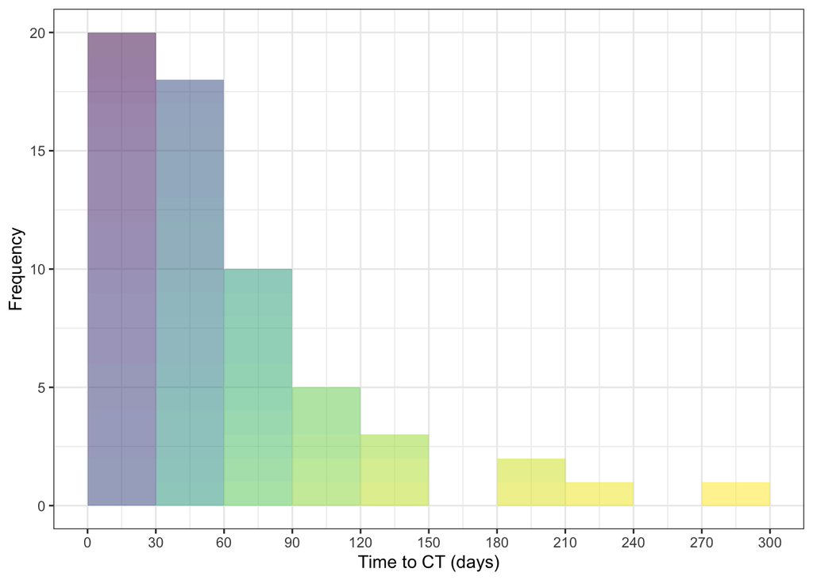

- These look abnormally distributed.
- Comparison of time to CT between screened and non-screened patients can be visualised as a boxplot, given that boxplots display the median and IQR which are the appropriate measures for these data:

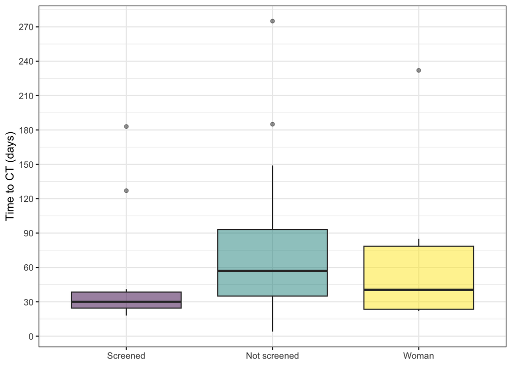

- These look different and this can be tested with a Mann Whitney U test to compare the groups with the alternative hypothesis that screened patients wait less time to have CTA.
- *p* = 0.02 - the alternative hypothesis can be accepted for screened vs non-screened men.

## 2.2 Time to ECHO

- 7 patients did not have a documented echocardiogram.
- 7 patients had ECHO prior to their imaging reaching treatment threshold size and did not have it repeated prior to fEVAR.
- That leaves 57 patients who had ECHO after reaching treatments threshold.
- The distribution of time to ECHO is shown in the following histogram:

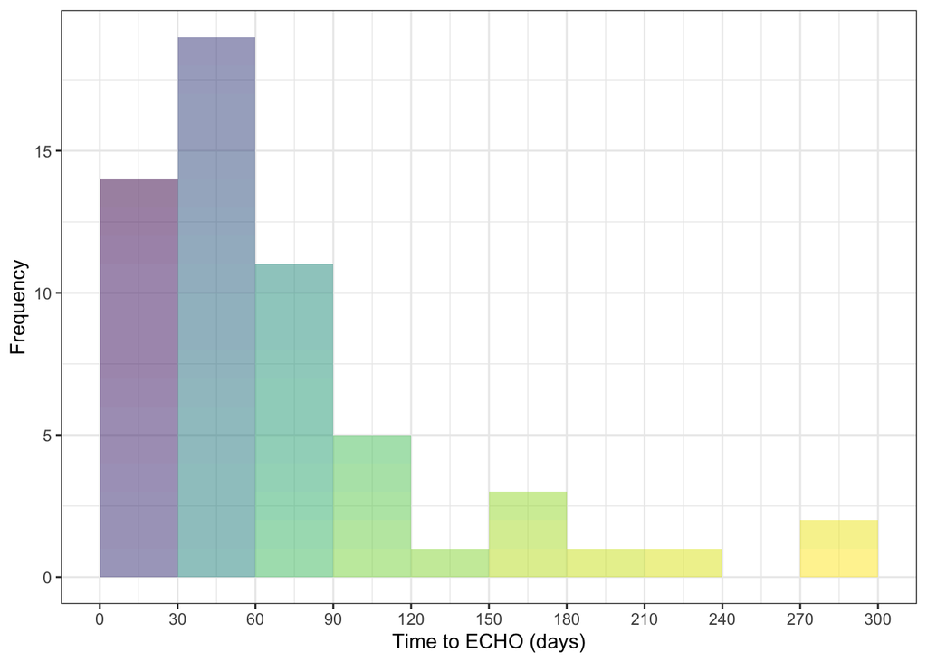

- These look abnormally distributed.
- Comparison of time to ECHO between screened and non-screened patients can be visualised as a boxplot, given that boxplots display the median and IQR which are the appropriate measures for these data:

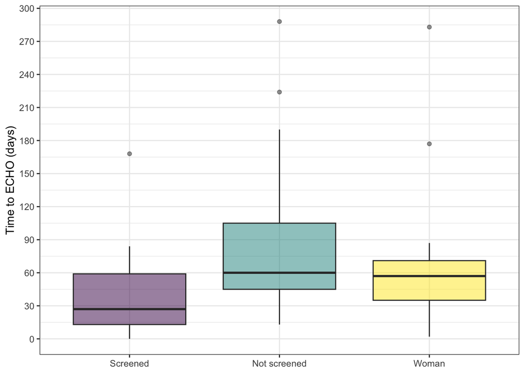

## 2.3 Time to PFT

- 13 patients did not have documented pulmonary function tests.
- 6 patients had PFTs prior to their imaging reaching treatment threshold size and did not have it repeated prior to fEVAR.
- That leaves 52 patients who had PFT after reaching treatments threshold.
- The distribution of time to PFT is shown in the following histogram:

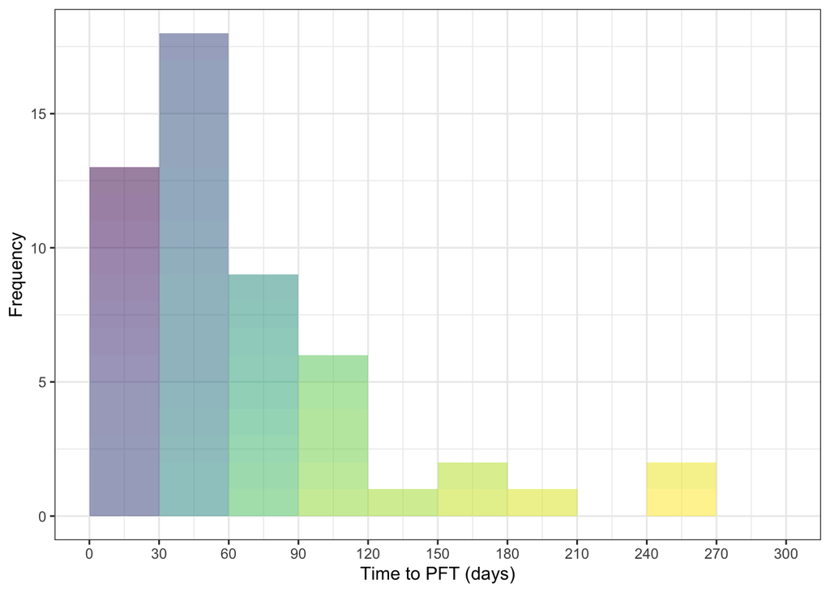

- These look abnormally distributed.
- Comparison of time to PFT between screened and non-screened patients can be visualised as a boxplot, given that boxplots display the median and IQR which are the appropriate measures for these data:

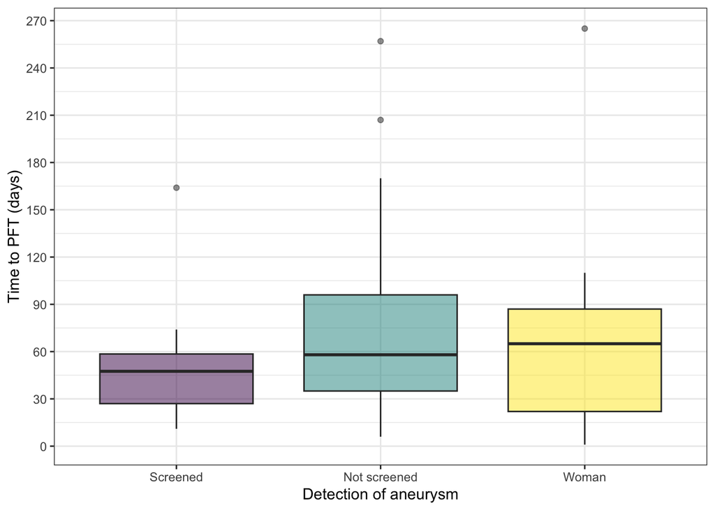

- These look similar and this can be tested with a Mann Whitney U test to compare the groups with the alternative hypothesis that screened patients wait less time to have PFT.
- For comparisons between the three groups, *p* = 0.08, 0.51, 0.72 - the null hypothesis that there is no difference in time to PFT cannot be rejected.

## 2.4 Time to MDT

- 7 patients did not have documented MDT discussion.
- 2 patients had MDT discussion prior to their imaging reaching treatment threshold size and did not have it repeated prior to fEVAR.
- That leaves 62 patients who had MDT after reaching treatments threshold.
- The distribution of time to MDT is shown in the following histogram:

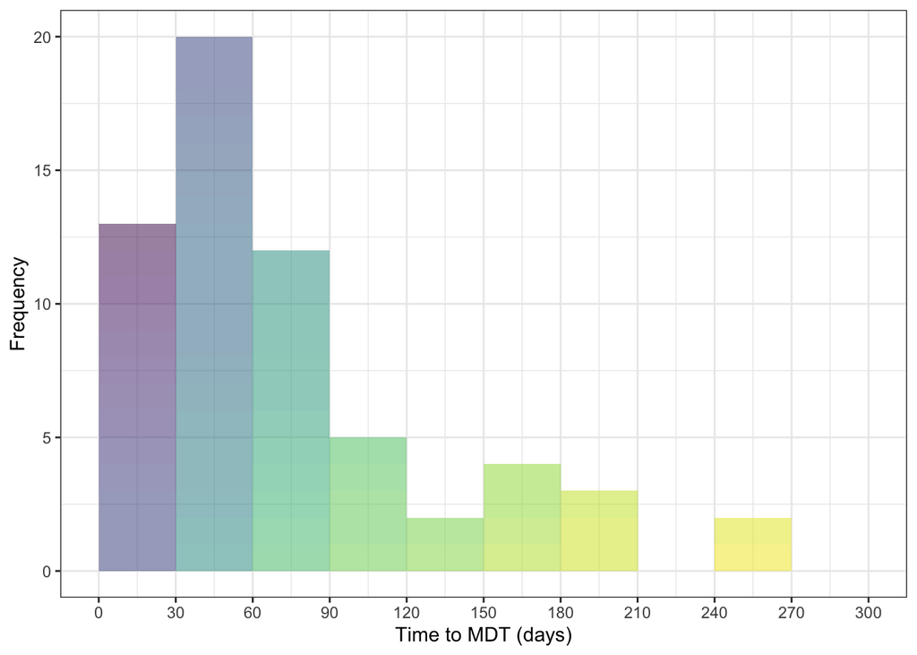

- These look abnormally distributed.
- Comparison of time to MDT between screened and non-screened patients can be visualised as a boxplot, given that boxplots display the median and IQR which are the appropriate measures for these data:

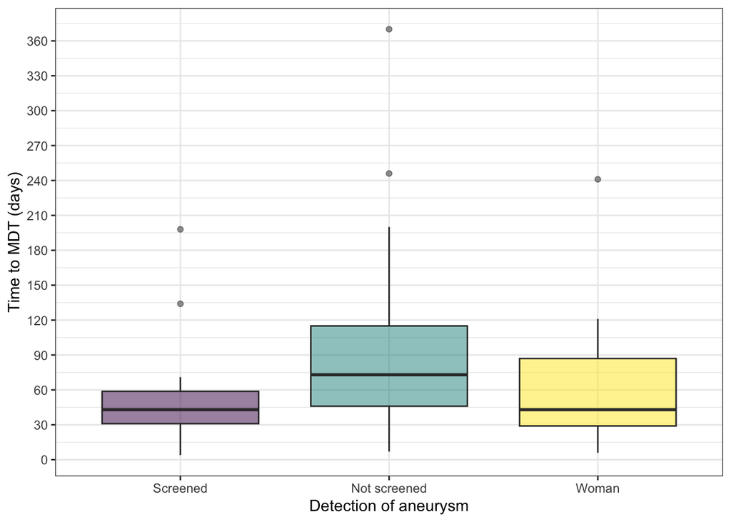

## 2.5 Time to fEVAR

- The distribution of time to fEVAR is shown in the following histogram:

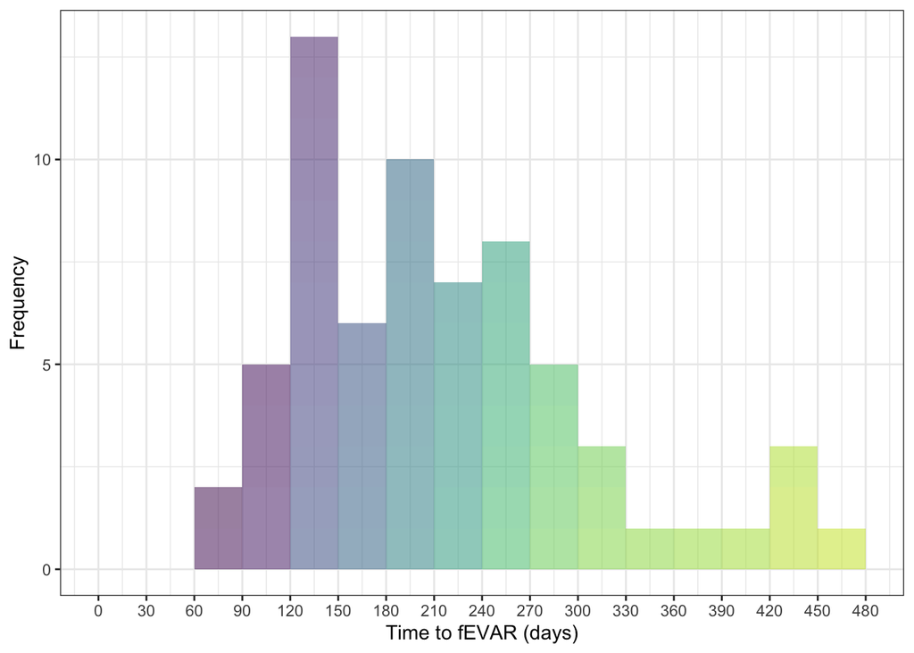

- These look abnormally distributed.
- Median and IQR for time to fEVAR are shown below:

| Characteristic | Value (days) |
| --- | --- |
| Median time | 204 |
| Interquartile range | 146 - 277.5 |

- Comparison of time to fEVAR between screened and non-screened patients can be visualised as a boxplot, given that boxplots display the median and IQR which are the appropriate measures for these data:

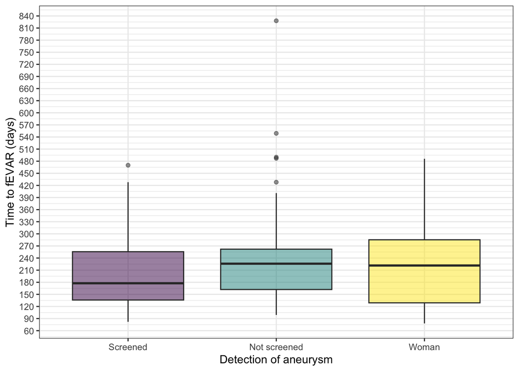

- These look similar and this can be tested with a Mann Whitney U test to compare the groups with the alternative hypothesis that screened patients wait less time to have fEVAR.
- For comparisons between the three groups, *p* = 0.21, 0.69, 0.69 - the null hypothesis that there is no difference in time to fEVAR cannot be rejected.

## 2.6 Comparative timeline

- The different time delays presented above can be shown together in a single boxplot:

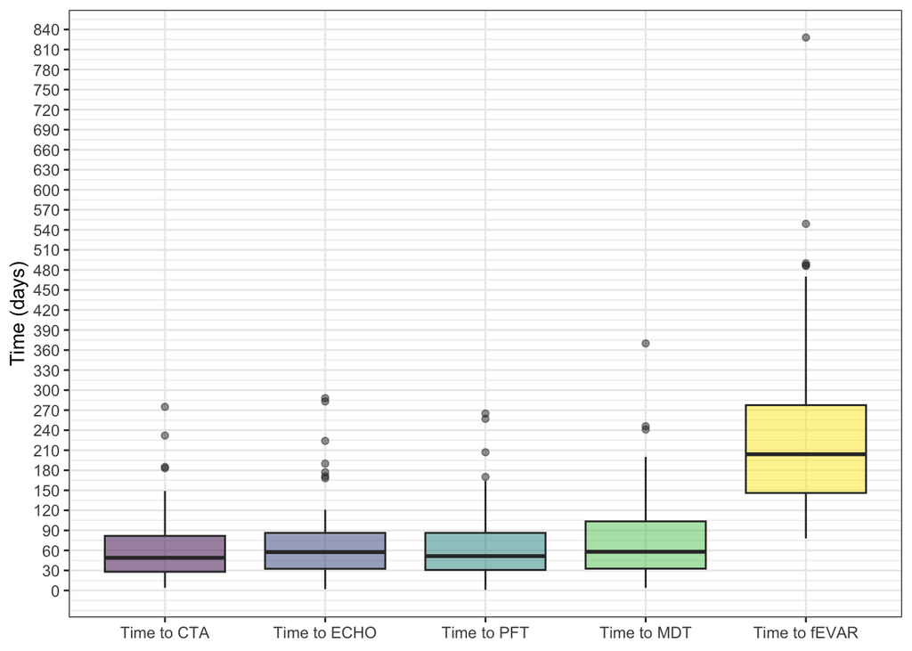

- It is visually apparent that CT imaging, ECHO, PFTs and MDT discussion are parallel investigations with none incurring a particular time penalty.
- There is a subsequent delay to the procedure, some of which can be accounted for by the time taken to manufacture a custom stent-graft.